# EEMP - Introduction to Python for Data Analysis

- Introductory course to working with python for data analysis
- Goals:
  - Overview of basic data structures and commands in python
  - Essential toolkit for data analysis in python, giving you a background in packages needed
  - By no means exhaustive, but should enable you to continue learning by yourself
- More commands will be introduced and practiced throughout the course

# Organizational Issues

- 3 python introductory sessions:

```
- 10/10/2022, 14:00 - 15:30
- 10/10/2022, 16:00 - 17:30
- (11/10/2022, 10:00 - 11:30)
```

# 8 Reasons Why You Should Learn Python

1. Consistently ranks among the most popular programming languages with a promising future
2. First-class tool for scientific computing tasks, especially for large datasets
3. Straightforward syntax and easy to learn
4. Very versatile and highly compatible
5. Free of charge since it is open source
6. Comprehensive standard libraries with large ecosystem of third-party packages
7. State-of-the-art for machine learning and data science in general
8. Great amount of resources and welcoming community

## Short Introduction to Google Colab

- Interactive computing environment in your browser
- Great tool to create and share documents that combine live code, visualizations, equations, text, images, videos etc.
- Allows working interactively
- Similar to Jupyter Notebook (http://www.jupyter.org), but even easier to get started without installing anything
- Get started at https://colab.research.google.com/

### Colab Basics

Cells can have 2 different modes:

- Edit mode (Enter)
- Command mode (Shift + Enter)

And 2 types:

- Text (Markdown) cell for narrative text, LaTeX-style formulas, weblinks, pictures etc. (click the "+ Text" button)
- Code cell for python code (click the "+ Code" button)

### Further Resources:

1. Watch https://www.youtube.com/watch?v=inN8seMm7UI
2. There are more tutorials on the Colab website and on YouTube
3. Check keyboard shortcuts (Tools $\rightarrow$ Keyboard Shortcuts)

### For Now:

## - Open your own notebook and type the code together with me (File $\rightarrow$ New notebook)

*Let's get started with Python*

## 1. Data Types and Operators

### Data Types:

- Integers
- Floats (decimal number)
- Strings ("text")
- Booleans (True/False)

```python
# Check python version
!python --version
```

```
Python 3.8.8
```

```python
# Integers
a = 10
b = 4

print(a)
print(type(a))
(a+b) * 3
```

```
10
<class 'int'>
```

```
42
```

```python
# Want to know more about a function and how to use it? Use the help() function or do a web search.
help(print)
help(type)
```

```
Help on built-in function print in module builtins:

print(...)
    print(value, ..., sep=' ', end='\n', file=sys.stdout, flush=False)

    Prints the values to a stream, or to sys.stdout by default.
    Optional keyword arguments:
    file:  a file-like object (stream); defaults to the current sys.stdout.
    sep:   string inserted between values, default a space.
    end:   string appended after the last value, default a newline.
    flush: whether to forcibly flush the stream.

Help on class type in module builtins:

class type(object)
 |  type(object_or_name, bases, dict)
 |  type(object) -> the object's type
 |  type(name, bases, dict) -> a new type
 |  Methods defined here:
 |  __call__(self, /, *args, **kwargs)
 |      Call self as a function.
 |  __delattr__(self, name, /)
 |      Implement delattr(self, name).
 |  __dir__(self, /)
 |      Specialized __dir__ implementation for types.
 |  __getattribute__(self, name, /)
 |      Return getattr(self, name).
 |  __init__(self, /, *args, **kwargs)
 |      Initialize self.  See help(type(self)) for accurate signature.
 |  __instancecheck__(self, instance, /)
 |      Check if an object is an instance.
 |  __repr__(self, /)
 |      Return repr(self).
 |  __setattr__(self, name, value, /)
 |      Implement setattr(self, name, value).
 |  __sizeof__(self, /)
 |      Return memory consumption of the type object.
 |  __subclasscheck__(self, subclass, /)
 |      Check if a class is a subclass.
 |  __subclasses__(self, /)
```

[output cut: 15 more lines]

```
 |  __dict__
 |  __text_signature__
 |  ----------------------------------------------------------------------
 |  Data and other attributes defined here:
 |  __base__ = <class 'object'>
 |      The base class of the class hierarchy.
 |      When called, it accepts no arguments and returns a new featureless
 |      instance that has no instance attributes and cannot be given any.
 |  __bases__ = (<class 'object'>,)
 |  __basicsize__ = 880
 |  __dictoffset__ = 264
 |  __flags__ = 2148291584
 |  __itemsize__ = 40
 |  __mro__ = (<class 'type'>, <class 'object'>)
 |  __weakrefoffset__ = 368
```

```python
# Floats
c = 1.5
d = 28.0

print(type(d))
c * d
```

```
<class 'float'>
```

```
42.0
```

```python
# Strings
question = "What is the answer to life, to the universe and everything?" # either denote with ""
answer = '42' # .. or ''

print(type(question))

question_answer = question + answer # strings can be added too!

print(question_answer)

print(question, " - ", answer)
print(question + ' - ' + answer)
```

```
<class 'str'>
What is the answer to life, to the universe and everything?42
What is the answer to life, to the universe and everything?  -  42
What is the answer to life, to the universe and everything? - 42
```

```python
# Booleans and True/False operators

print(True == 1) # True is encoded as 1
print(False == 1) # False is encoded as 0

print(not True) # We can inverse a boolean with "not"
print(True + True) # We can also add booleans
```

```
True
False
False
2
```

```python
# We can evaluate the truth of a statement with the different operators ==, !=, >, <, >=, <=, not
# -> the output is always a boolean

print(True > False)
print(answer == '42')
print(4 >= 5)
print(10 != 0)
```

```
True
True
False
True
```

```python
# We can also combine different conditions with and, &, or
# Watch out with bitwise operators such as &

print(2>1 and 2<3)
print(1==1 & 2==2)
print(0==1 & 2==0)
print(2==1 or 2<3)
```

```
True
False
True
True
```

```python
# If-statements can be used to execute code only if a certain condition is fulfilled

answer = '42'

# Indentation after if-condition is needed (convention is to indent with 4 spaces)
if answer == "42":
    print("This is the answer to life, to the universe and everything.")
```

```
This is the answer to life, to the universe and everything.
```

```python
# We can also include additional conditions

answer = '5'

if answer == "42":
    print("This is the answer to life, to the universe and everything.")
elif answer=="41" or answer=='43':
    print("This is nearly the answer to life, to the universe and everything.")
else:
    print("This is not the answer to life, to the universe and everything.")
```

```
This is not the answer to life, to the universe and everything.
```

## 2. Python Lists

- Standard mutable multi-element container in Python
- Denoted by squared brackets [ ]

```python
# Python lists can contain integers...
l1 = list(range(10))
print(l1, type(l1[0]))

# ...strings
l2 = list(str(i) for i in l1)
print(l2, type(l2[0]))


# ...or a combination of different data types.
l3 = [1.2, 42, 'Yes', True]
print(l3)
print([type(i) for i in l3])
```

```
[0, 1, 2, 3, 4, 5, 6, 7, 8, 9] <class 'int'>
['0', '1', '2', '3', '4', '5', '6', '7', '8', '9'] <class 'str'>
[1.2, 42, 'Yes', True]
[<class 'float'>, <class 'int'>, <class 'str'>, <class 'bool'>]
```

```python
# You can access each element of a list by calling its index

print(l1[0]) # Python is a zero-indexed language, i.e. this gives you the first element of the list
print(l2[-1]) # You can also access the list from the end, i.e. this gives you the last element of the list
print(l2[-2]) # This gives the second last element

# You can slice the list and extract only a certain range

print(l3[0:3]) # First index is inclusive, last index is exclusive
```

```
0
9
8
[1.2, 42, 'Yes']
```

## 3. Loops

- We can loop over the values in a list

```python
for item in ['life', 'the universe', 'everything']:
    print('The answer to', item, 'is 42.')
```

```
The answer to life is 42.
The answer to the universe is 42.
The answer to everything is 42.
```

```python
even_numbers = list(range(0, 10, 2)) # Check help(range) to find out about the options within the function
print(even_numbers)

result = 0
for number in even_numbers:
    result += number # This is the inplace version of reassigning result = result + number, the outcome is identical
    print(result)
```

```
[0, 2, 4, 6, 8]
0
2
6
12
20
```

## 4. Functions

- Python is also suitable for writing functions
- Very good for operations that are done repeatedly, but have no built-in functions
- However, whenever there are built-in functions, always use those; they are usually computationally more efficient
- We will give you a short idea of what a function means and what it looks like, but writing functions is not the focus of the course

```python
def f(x):
    '''This function squares its numerical input'''
    return x**2
```

```python
f(3)
```

```
9
```

## 5. Libraries

### 5.1 NumPy Library

*Provides numeric vector and matrix operations*

- NumPy's "ndarray" is another of the basic formats in which data can be stored
- Similar to python built-in lists (see 2), but lack its multi-type flexibility; i.e. can only contain one data type
- However, in contrast to lists, ndarrays are more efficient in storing and manipulating data, which is important as data become bigger
- Building blocks for many other packages (see 5.2)

```python
# Before we can use a package the first time, we need to import it (given that we have already installed it)
# The "as np" indicates the alias we can use to call the package from now on
import numpy as np
```

```python
# ndarrays
array1 = np.array([0, 1, 5, 15, 2])
print(array1, type(array1))
array2 = np.arange(5)
print(array2)

# ndarrays can also be added to each other
array3 = array1 + array2
print(array3)
```

```
[ 0  1  5 15  2] <class 'numpy.ndarray'>
[0 1 2 3 4]
[ 0  2  7 18  6]
```

```python
# We can also build matrices from ndarrays

matrix1 = np.array([[1,0],[0,1]])
print(matrix1, type(matrix1))

matrix2 = np.array([array1, array2, array1 + array3])
print(matrix2)

matrix3 = matrix2 + array1
print(matrix3)
```

```
[[1 0]
 [0 1]] <class 'numpy.ndarray'>
[[ 0  1  5 15  2]
 [ 0  1  2  3  4]
 [ 0  3 12 33  8]]
[[ 0  2 10 30  4]
 [ 0  2  7 18  6]
 [ 0  4 17 48 10]]
```

```python
# We can then work with these arrays and matrices using numpy methods and functions

matrix2_t = matrix2.transpose()
print(matrix2_t)
print(np.shape(matrix2_t)) # gives you a 5×3 matrix from the original 3×5 matrix
```

```
[[ 0  0  0]
 [ 1  1  3]
 [ 5  2 12]
 [15  3 33]
 [ 2  4  8]]
(5, 3)
```

```python
# As with lists, you can access elements within an array in a similar fashion

print(array1[0:4:2]) # slicing scheme: array[start:stop:step]

print(matrix2_t[1,2]) # takes only the element from the row with index 1 and the column with index 2
print(matrix2_t[0:2,0:2], np.shape(matrix2_t[0:2,0:2])) # gives you a 2×2 matrix from the 5×3 original matrix
```

```
[0 5]
3
[[0 0]
 [1 1]] (2, 2)
```

### 5.2 Pandas Library

*Provides the DataFrame, which is the building block for working with data*

- Newer package built on top of NumPy
- A Series is the Pandas equivalent to a NumPy array
  - However, Series (and DataFrames) have explicitly defined row (and column) labels attached as compared to implicitly defined simple integer indices in NumPy
- A DataFrame is a 2-dimensional multi-array data structure, i.e. consist of multiple Series
- Often contain heterogenous types and/or missing values

```python
# Again, we have to import the package first
import pandas as pd
```

```python
# A series is a one-dimensional array of indexed data

series1 = pd.Series([0, 2, 4, 6])

print(series1)

print(series1.values) # can access the values within a Series

print(series1.index) # can access the respective indices of a Series
```

```
0    0
1    2
2    4
3    6
dtype: int64
[0 2 4 6]
RangeIndex(start=0, stop=4, step=1)
```

```python
# Indices don't need to be numerical, but could also be strings

series2 = pd.Series([1, 3, 6], index=['a', 'b', 'c'])

print(series2)
```

```
a    1
b    3
c    6
dtype: int64
```

```python
# Now, let's read in an actual data set with several columns and numerous rows, and start working with DataFrames

path_to_data = "https://raw.githubusercontent.com/lemepe/EEMP/master/python_intro/Employee_data.csv"
employee_data = pd.read_csv(path_to_data)

# We can inspect the data by looking at the first few rows

employee_data.head() # by default, this gives you the first 5 observations in the dataframe
```

|  | Age | Attrition | BusinessTravel | DailyRate | Department | DistanceFromHome | Education | EducationField | EmployeeCount | EmployeeNumber | ... | RelationshipSatisfaction | StandardHours | StockOptionLevel | TotalWorkingYears | TrainingTimesLastYear | WorkLifeBalance | YearsAtCompany | YearsInCurrentRole | YearsSinceLastPromotion | YearsWithCurrManager |
| --- | --- | --- | --- | --- | --- | --- | --- | --- | --- | --- | --- | --- | --- | --- | --- | --- | --- | --- | --- | --- | --- |
| 0 | 41 | Yes | Travel_Rarely | 1102 | Sales | 1 | 2 | Life Sciences | 1 | 1 | ... | 1 | 80 | 0 | 8 | 0 | 1 | 6 | 4 | 0 | 5 |
| 1 | 49 | No | Travel_Frequently | 279 | Research & Development | 8 | 1 | Life Sciences | 1 | 2 | ... | 4 | 80 | 1 | 10 | 3 | 3 | 10 | 7 | 1 | 7 |
| 2 | 37 | Yes | Travel_Rarely | 1373 | Research & Development | 2 | 2 | Other | 1 | 4 | ... | 2 | 80 | 0 | 7 | 3 | 3 | 0 | 0 | 0 | 0 |
| 3 | 33 | No | Travel_Frequently | 1392 | Research & Development | 3 | 4 | Life Sciences | 1 | 5 | ... | 3 | 80 | 0 | 8 | 3 | 3 | 8 | 7 | 3 | 0 |
| 4 | 27 | No | Travel_Rarely | 591 | Research & Development | 2 | 1 | Medical | 1 | 7 | ... | 4 | 80 | 1 | 6 | 3 | 3 | 2 | 2 | 2 | 2 |

5 rows × 35 columns

### Exploratory data analysis (EDA)

```python
# Shape of the DataFrame in form of a tuple (#rows, #cols)
employee_data.shape
```

```
(1470, 35)
```

```python
# List all column indices
employee_data.columns
```

```
Index(['Age', 'Attrition', 'BusinessTravel', 'DailyRate', 'Department',
       'DistanceFromHome', 'Education', 'EducationField', 'EmployeeCount',
       'EmployeeNumber', 'EnvironmentSatisfaction', 'Gender', 'HourlyRate',
       'JobInvolvement', 'JobLevel', 'JobRole', 'JobSatisfaction',
       'MaritalStatus', 'MonthlyIncome', 'MonthlyRate', 'NumCompaniesWorked',
       'Over18', 'OverTime', 'PercentSalaryHike', 'PerformanceRating',
       'RelationshipSatisfaction', 'StandardHours', 'StockOptionLevel',
       'TotalWorkingYears', 'TrainingTimesLastYear', 'WorkLifeBalance',
       'YearsAtCompany', 'YearsInCurrentRole', 'YearsSinceLastPromotion',
       'YearsWithCurrManager'],
      dtype='object')
```

```python
# Overview of columns, non-null entries, and datatypes
employee_data.info()
```

```
<class 'pandas.core.frame.DataFrame'>
RangeIndex: 1470 entries, 0 to 1469
Data columns (total 35 columns):
 #   Column                    Non-Null Count  Dtype
---  ------                    --------------  -----
 0   Age                       1470 non-null   int64
 1   Attrition                 1470 non-null   object
 2   BusinessTravel            1470 non-null   object
 3   DailyRate                 1470 non-null   int64
 4   Department                1470 non-null   object
 5   DistanceFromHome          1470 non-null   int64
 6   Education                 1470 non-null   int64
 7   EducationField            1470 non-null   object
 8   EmployeeCount             1470 non-null   int64
 9   EmployeeNumber            1470 non-null   int64
```

[output cut: 27 more lines]

```python
# Summary statistics of the dataset

pd.set_option('display.max_columns', 200) # sets the maximum number of displayed columns to 200

employee_data.describe()
```

|  | Age | DailyRate | DistanceFromHome | Education | EmployeeCount | EmployeeNumber | EnvironmentSatisfaction | HourlyRate | JobInvolvement | JobLevel | JobSatisfaction | MonthlyIncome | MonthlyRate | NumCompaniesWorked | PercentSalaryHike | PerformanceRating | RelationshipSatisfaction | StandardHours | StockOptionLevel | TotalWorkingYears | TrainingTimesLastYear | WorkLifeBalance | YearsAtCompany | YearsInCurrentRole | YearsSinceLastPromotion | YearsWithCurrManager |
| --- | --- | --- | --- | --- | --- | --- | --- | --- | --- | --- | --- | --- | --- | --- | --- | --- | --- | --- | --- | --- | --- | --- | --- | --- | --- | --- |
| count | 1470.000000 | 1470.000000 | 1470.000000 | 1470.000000 | 1470.0 | 1470.000000 | 1470.000000 | 1470.000000 | 1470.000000 | 1470.000000 | 1470.000000 | 1470.000000 | 1470.000000 | 1470.000000 | 1470.000000 | 1470.000000 | 1470.000000 | 1470.0 | 1470.000000 | 1470.000000 | 1470.000000 | 1470.000000 | 1470.000000 | 1470.000000 | 1470.000000 | 1470.000000 |
| mean | 36.923810 | 802.485714 | 9.192517 | 2.912925 | 1.0 | 1024.865306 | 2.721769 | 65.891156 | 2.729932 | 2.063946 | 2.728571 | 6502.931293 | 14313.103401 | 2.693197 | 15.209524 | 3.153741 | 2.712245 | 80.0 | 0.793878 | 11.279592 | 2.799320 | 2.761224 | 7.008163 | 4.229252 | 2.187755 | 4.123129 |
| std | 9.135373 | 403.509100 | 8.106864 | 1.024165 | 0.0 | 602.024335 | 1.093082 | 20.329428 | 0.711561 | 1.106940 | 1.102846 | 4707.956783 | 7117.786044 | 2.498009 | 3.659938 | 0.360824 | 1.081209 | 0.0 | 0.852077 | 7.780782 | 1.289271 | 0.706476 | 6.126525 | 3.623137 | 3.222430 | 3.568136 |
| min | 18.000000 | 102.000000 | 1.000000 | 1.000000 | 1.0 | 1.000000 | 1.000000 | 30.000000 | 1.000000 | 1.000000 | 1.000000 | 1009.000000 | 2094.000000 | 0.000000 | 11.000000 | 3.000000 | 1.000000 | 80.0 | 0.000000 | 0.000000 | 0.000000 | 1.000000 | 0.000000 | 0.000000 | 0.000000 | 0.000000 |
| 25% | 30.000000 | 465.000000 | 2.000000 | 2.000000 | 1.0 | 491.250000 | 2.000000 | 48.000000 | 2.000000 | 1.000000 | 2.000000 | 2911.000000 | 8047.000000 | 1.000000 | 12.000000 | 3.000000 | 2.000000 | 80.0 | 0.000000 | 6.000000 | 2.000000 | 2.000000 | 3.000000 | 2.000000 | 0.000000 | 2.000000 |
| 50% | 36.000000 | 802.000000 | 7.000000 | 3.000000 | 1.0 | 1020.500000 | 3.000000 | 66.000000 | 3.000000 | 2.000000 | 3.000000 | 4919.000000 | 14235.500000 | 2.000000 | 14.000000 | 3.000000 | 3.000000 | 80.0 | 1.000000 | 10.000000 | 3.000000 | 3.000000 | 5.000000 | 3.000000 | 1.000000 | 3.000000 |
| 75% | 43.000000 | 1157.000000 | 14.000000 | 4.000000 | 1.0 | 1555.750000 | 4.000000 | 83.750000 | 3.000000 | 3.000000 | 4.000000 | 8379.000000 | 20461.500000 | 4.000000 | 18.000000 | 3.000000 | 4.000000 | 80.0 | 1.000000 | 15.000000 | 3.000000 | 3.000000 | 9.000000 | 7.000000 | 3.000000 | 7.000000 |
| max | 60.000000 | 1499.000000 | 29.000000 | 5.000000 | 1.0 | 2068.000000 | 4.000000 | 100.000000 | 4.000000 | 5.000000 | 4.000000 | 19999.000000 | 26999.000000 | 9.000000 | 25.000000 | 4.000000 | 4.000000 | 80.0 | 3.000000 | 40.000000 | 6.000000 | 4.000000 | 40.000000 | 18.000000 | 15.000000 | 17.000000 |

```python
# To get an idea about the different values contained within a specific column, we can use the .unique() method
# Since unique takes the values in order of appearance, we use the sorted function on top of it
# We can access this particular Series in the DataFrame with [] and the respective column label

print(sorted(employee_data['DistanceFromHome'].unique()))

print(sorted(employee_data['WorkLifeBalance'].unique()))
```

```
[1, 2, 3, 4, 5, 6, 7, 8, 9, 10, 11, 12, 13, 14, 15, 16, 17, 18, 19, 20, 21, 22, 23, 24, 25, 26, 27, 28, 29]
[1, 2, 3, 4]
```

```python
# If we want to know more about the distribution of certain values or categories, we can use value_counts()

print(employee_data['WorkLifeBalance'].value_counts()) # gives the frequency counts in descending order

print(employee_data['WorkLifeBalance'].value_counts(normalize=True)) # alternatively, we can show percentages
```

```
3    893
2    344
4    153
1     80
Name: WorkLifeBalance, dtype: int64
3    0.607483
2    0.234014
4    0.104082
1    0.054422
Name: WorkLifeBalance, dtype: float64
```

```python
# We can slice the data by labels using loc

employee_data.loc[0:99] # extracts the first 100 observations by referring to the explicitly defined index
```

|  | Age | Attrition | BusinessTravel | DailyRate | Department | DistanceFromHome | Education | EducationField | EmployeeCount | EmployeeNumber | EnvironmentSatisfaction | Gender | HourlyRate | JobInvolvement | JobLevel | JobRole | JobSatisfaction | MaritalStatus | MonthlyIncome | MonthlyRate | NumCompaniesWorked | Over18 | OverTime | PercentSalaryHike | PerformanceRating | RelationshipSatisfaction | StandardHours | StockOptionLevel | TotalWorkingYears | … |
| --- | --- | --- | --- | --- | --- | --- | --- | --- | --- | --- | --- | --- | --- | --- | --- | --- | --- | --- | --- | --- | --- | --- | --- | --- | --- | --- | --- | --- | --- | --- |
| 0 | 41 | Yes | Travel_Rarely | 1102 | Sales | 1 | 2 | Life Sciences | 1 | 1 | 2 | Female | 94 | 3 | 2 | Sales Executive | 4 | Single | 5993 | 19479 | 8 | Y | Yes | 11 | 3 | 1 | 80 | 0 | 8 | … |
| 1 | 49 | No | Travel_Frequently | 279 | Research & Development | 8 | 1 | Life Sciences | 1 | 2 | 3 | Male | 61 | 2 | 2 | Research Scientist | 2 | Married | 5130 | 24907 | 1 | Y | No | 23 | 4 | 4 | 80 | 1 | 10 | … |
| 2 | 37 | Yes | Travel_Rarely | 1373 | Research & Development | 2 | 2 | Other | 1 | 4 | 4 | Male | 92 | 2 | 1 | Laboratory Technician | 3 | Single | 2090 | 2396 | 6 | Y | Yes | 15 | 3 | 2 | 80 | 0 | 7 | … |
| 3 | 33 | No | Travel_Frequently | 1392 | Research & Development | 3 | 4 | Life Sciences | 1 | 5 | 4 | Female | 56 | 3 | 1 | Research Scientist | 3 | Married | 2909 | 23159 | 1 | Y | Yes | 11 | 3 | 3 | 80 | 0 | 8 | … |
| 4 | 27 | No | Travel_Rarely | 591 | Research & Development | 2 | 1 | Medical | 1 | 7 | 1 | Male | 40 | 3 | 1 | Laboratory Technician | 2 | Married | 3468 | 16632 | 9 | Y | No | 12 | 3 | 4 | 80 | 1 | 6 | … |
| ... | ... | ... | ... | ... | ... | ... | ... | ... | ... | ... | ... | ... | ... | ... | ... | ... | ... | ... | ... | ... | ... | ... | ... | ... | ... | ... | ... | ... | ... | … |
| 95 | 54 | No | Travel_Rarely | 1217 | Research & Development | 2 | 4 | Technical Degree | 1 | 126 | 1 | Female | 60 | 3 | 3 | Research Director | 3 | Married | 13549 | 24001 | 9 | Y | No | 12 | 3 | 1 | 80 | 1 | 16 | … |
| 96 | 24 | No | Travel_Rarely | 1353 | Sales | 3 | 2 | Other | 1 | 128 | 1 | Female | 33 | 3 | 2 | Sales Executive | 3 | Married | 4999 | 17519 | 0 | Y | No | 21 | 4 | 1 | 80 | 1 | 4 | … |
| 97 | 28 | No | Non-Travel | 120 | Sales | 4 | 3 | Medical | 1 | 129 | 2 | Male | 43 | 3 | 2 | Sales Executive | 3 | Married | 4221 | 8863 | 1 | Y | No | 15 | 3 | 2 | 80 | 0 | 5 | … |
| 98 | 58 | No | Travel_Rarely | 682 | Sales | 10 | 4 | Medical | 1 | 131 | 4 | Male | 37 | 3 | 4 | Sales Executive | 3 | Single | 13872 | 24409 | 0 | Y | No | 13 | 3 | 3 | 80 | 0 | 38 | … |
| 99 | 44 | No | Non-Travel | 489 | Research & Development | 23 | 3 | Medical | 1 | 132 | 2 | Male | 67 | 3 | 2 | Laboratory Technician | 2 | Married | 2042 | 25043 | 4 | Y | No | 12 | 3 | 3 | 80 | 1 | 17 | … |

100 rows × 35 columns

```python
# The index can also be a string, as in the case of the columns

employee_data.loc[0:99, ['MonthlyIncome', 'Department']]
```

|  | MonthlyIncome | Department |
| --- | --- | --- |
| 0 | 5993 | Sales |
| 1 | 5130 | Research & Development |
| 2 | 2090 | Research & Development |
| 3 | 2909 | Research & Development |
| 4 | 3468 | Research & Development |
| ... | ... | ... |
| 95 | 13549 | Research & Development |
| 96 | 4999 | Sales |
| 97 | 4221 | Sales |
| 98 | 13872 | Sales |
| 99 | 2042 | Research & Development |

100 rows × 2 columns

```python
# The row labels need not be numbers either

data = [['A', 10],
        ['B', 20],
        ['C', 30]]
df = pd.DataFrame(data, columns=['Letter', 'Number'], index=['one', 'two', 'three'])
print('We defined this DataFrame: \n', df)


print('\nSecond row as pandas Series:')
print(df.loc['two'])

print('\nSecond row as pandas DataFrame:')
print(df.loc[['two']])
```

```
We defined this DataFrame:
       Letter  Number
one        A      10
two        B      20
three      C      30

Second row as pandas Series:
Letter     B
Number    20
Name: two, dtype: object

Second row as pandas DataFrame:
    Letter  Number
two      B      20
```

```python
# In contrast, iloc uses the implicitly defined row and column indices

employee_data.iloc[0:100, [4, 18]] # sliced both row- and column-wise by implicit indices
```

|  | Department | MonthlyIncome |
| --- | --- | --- |
| 0 | Sales | 5993 |
| 1 | Research & Development | 5130 |
| 2 | Research & Development | 2090 |
| 3 | Research & Development | 2909 |
| 4 | Research & Development | 3468 |
| ... | ... | ... |
| 95 | Research & Development | 13549 |
| 96 | Sales | 4999 |
| 97 | Sales | 4221 |
| 98 | Sales | 13872 |
| 99 | Research & Development | 2042 |

100 rows × 2 columns

```python
# Select subset of rows with a condition and assign it to a new DataFrame
exit_data = employee_data[employee_data['Attrition']=='Yes'].copy() # use .copy() to avoid SettingWithCopyWarning: https://www.dataquest.io/blog/settingwithcopywarning/

# Show only certain columns
print(exit_data[['MonthlyIncome', 'Department']].head(10))

# Select age and income for those under 35
u35_mon_inc = employee_data.loc[employee_data['Age']<35, ['Age', 'MonthlyIncome']]
print(u35_mon_inc)
```

```
    MonthlyIncome              Department
0            5993                   Sales
2            2090  Research & Development
14           2028  Research & Development
21           3407                   Sales
24           2960  Research & Development
26           3919  Research & Development
33           2086                   Sales
34           2293  Research & Development
36           2683                   Sales
42           2293  Research & Development
      Age  MonthlyIncome
3      33           2909
4      27           3468
5      32           3068
7      30           2693
11     29           4193
...   ...            ...
1460   29           3785
1463   31           9936
1464   26           2966
1467   27           6142
1469   34           4404

[651 rows x 2 columns]
```

### Descriptives statistics

- Overview of pandas aggregation methods:

[figure not shown]

```python
# Distribution of exits across departments
print(exit_data['Department'].value_counts(normalize=True), '\n')

# Mean age of exits
mean_age_exited = exit_data['Age'].mean()
print(mean_age_exited, '\n')

# Mean age of exits across departments
mean_age_exited_by_dep = exit_data['Age'].groupby(exit_data['Department']).mean() # groupby allows for groupwise calculations
print(mean_age_exited_by_dep, '\n')

# Mean age across all employees
mean_age = employee_data['Age'].mean()
print(mean_age, '\n')
```

```
Research & Development    0.561181
Sales                     0.388186
Human Resources           0.050633
Name: Department, dtype: float64

33.607594936708864

Department
Human Resources           30.083333
Research & Development    33.473684
Sales                     34.260870
Name: Age, dtype: float64

36.923809523809524
```

```python
# Create new variables

employee_data['dummy_exit'] = 0 # create column 'dummy_exit' with only zeros
employee_data.loc[employee_data['Attrition']=='Yes', 'dummy_exit'] = 1 # replace with one if an employee left the firm
print(employee_data[['Attrition', 'dummy_exit']].head())

employee_data['dummy_u35'] = employee_data['Age']<35 # Dummy with boolean when attrition equal to 'Yes'
print(employee_data[['Age', 'dummy_u35']].head())

# Alternatively, pandas has an already integrated command to create dummies from categorial variables

employee_data_dummies = pd.get_dummies(employee_data, columns=['BusinessTravel', 'EducationField'])

employee_data_dummies.iloc[:, -9:].head()
```

```
  Attrition  dummy_exit
0       Yes           1
1        No           0
2       Yes           1
3        No           0
4        No           0
   Age  dummy_u35
0   41      False
1   49      False
2   37      False
3   33       True
4   27       True
```

|  | BusinessTravel_Non-Travel | BusinessTravel_Travel_Frequently | BusinessTravel_Travel_Rarely | EducationField_Human Resources | EducationField_Life Sciences | EducationField_Marketing | EducationField_Medical | EducationField_Other | EducationField_Technical Degree |
| --- | --- | --- | --- | --- | --- | --- | --- | --- | --- |
| 0 | 0 | 0 | 1 | 0 | 1 | 0 | 0 | 0 | 0 |
| 1 | 0 | 1 | 0 | 0 | 1 | 0 | 0 | 0 | 0 |
| 2 | 0 | 0 | 1 | 0 | 0 | 0 | 0 | 1 | 0 |
| 3 | 0 | 1 | 0 | 0 | 1 | 0 | 0 | 0 | 0 |
| 4 | 0 | 0 | 1 | 0 | 0 | 0 | 1 | 0 | 0 |

```python
# Calculate percentage of employees that left the company

employee_data['dummy_exit'].sum()/len(employee_data) # len() gives the length, i.e. number of rows of an array or df
```

```
0.16122448979591836
```

```python
# Alternatively using mean()

employee_data['dummy_exit'].mean()
```

```
0.16122448979591836
```

```python
# Alternatively using value_counts()

employee_data['dummy_exit'].value_counts(normalize=True)
```

```
0    0.838776
1    0.161224
Name: dummy_exit, dtype: float64
```

```python
# With the groupby() function, we can split the dataset by categories and do calculations on these subgroups

employee_data['dummy_exit'].groupby(employee_data['Department']).value_counts(normalize=True)
```

```
Department              dummy_exit
Human Resources         0             0.809524
                        1             0.190476
Research & Development  0             0.861602
                        1             0.138398
Sales                   0             0.793722
                        1             0.206278
Name: dummy_exit, dtype: float64
```

### 5.3 Visualization Libraries

*Provide plotting and visualization support*

#### Matplotlib Library

- Original visualization library built on NumPy arrays
- Conceived in 2002 to enable MATLAB-style plotting
- We will only provide a quick overview, for more information see matplotlib documentation
- https://matplotlib.org/3.1.1/gallery/index.html

```python
import matplotlib.pyplot as plt
```

```python
# Here we define the plotstyle to be used
# check https://matplotlib.org/3.1.1/gallery/style_sheets/style_sheets_reference.html for an overview of style sheets

plt.style.use('ggplot')
```

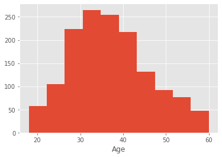

```python
# Histogram with frequencies
plt.hist(employee_data['Age'])
plt.xlabel('Age')
plt.show()
```

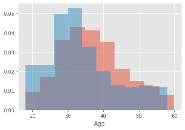

```python
plt.hist(employee_data['Age'], density=True, alpha=0.5)
plt.hist(exit_data['Age'], density=True, alpha=0.5)
plt.xlabel('Age')
plt.show()
```

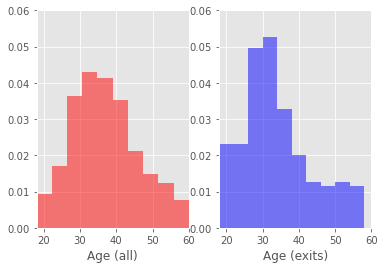

```python
# We can also combine multiple plots with plt.subplot(#rows, #cols, position)

plt.subplot(1, 2, 1)
plt.hist(employee_data['Age'], density=True, color='red', alpha=0.5)
plt.xlabel('Age (all)')
plt.xlim(18, 60)
plt.ylim(0, 0.06)

plt.subplot(1, 2, 2)
plt.hist(exit_data['Age'], density=True, color='blue', alpha=0.5)
plt.xlabel('Age (exits)')
plt.xlim(18, 60)
plt.ylim(0, 0.06)

plt.show()
```

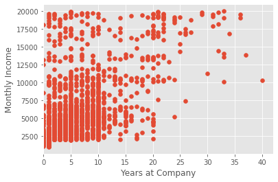

```python
# Scatter plot
plt.scatter(employee_data['YearsAtCompany'], employee_data['MonthlyIncome'])
plt.xlim(0,)
plt.xlabel('Years at Company')
plt.ylabel('Monthly Income')
```

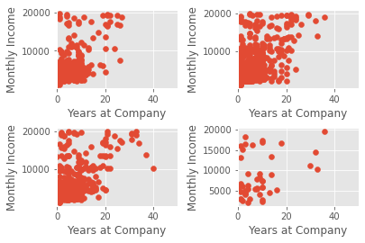

```python
plt.subplot(2, 2, 1)
plt.scatter(employee_data[employee_data['Education']==2]['YearsAtCompany'],
            employee_data[employee_data['Education']==2]['MonthlyIncome'])
plt.xlim(0, 50)
plt.xlabel('Years at Company')
plt.ylabel('Monthly Income')

plt.subplot(2, 2, 2)
plt.scatter(employee_data[employee_data['Education']==3]['YearsAtCompany'],
            employee_data[employee_data['Education']==3]['MonthlyIncome'])
plt.xlim(0, 50)
plt.xlabel('Years at Company')
plt.ylabel('Monthly Income')

plt.subplot(2, 2, 3)
plt.scatter(employee_data[employee_data['Education']==4]['YearsAtCompany'],
            employee_data[employee_data['Education']==4]['MonthlyIncome'])
plt.xlim(0, 50)
plt.xlabel('Years at Company')
plt.ylabel('Monthly Income')

plt.subplot(2, 2, 4)
plt.scatter(employee_data[employee_data['Education']==5]['YearsAtCompany'],
            employee_data[employee_data['Education']==5]['MonthlyIncome'])
plt.xlim(0, 50)
plt.xlabel('Years at Company')
plt.ylabel('Monthly Income')

plt.subplots_adjust(hspace=0.5, wspace=0.5)
plt.show()
```

#### Seaborn Library

- Newer library with more visually appealing and simpler to use toolkit
- Better suited for visualizing DataFrame structures
- Again, we only provide a quick overview, see documentation for more details
- https://seaborn.pydata.org/examples/index.html

```python
import seaborn as sns
```

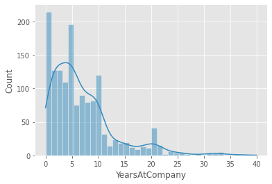

```python
sns.histplot(employee_data['MonthlyIncome'], x=employee_data['YearsAtCompany'], kde=True)
```

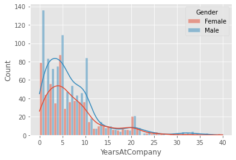

```python
sns.histplot(data=employee_data, x='YearsAtCompany', hue='Gender', multiple='dodge', kde=True)
```

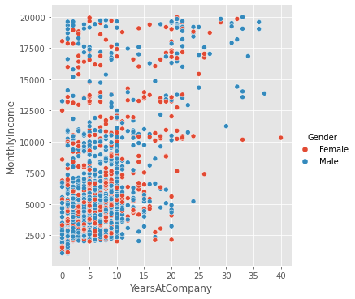

```python
sns.relplot(x='YearsAtCompany', y='MonthlyIncome', data=employee_data, hue='Gender')
```

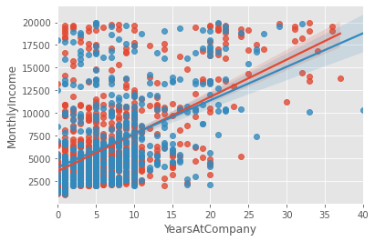

```python
sns.regplot(x='YearsAtCompany', y='MonthlyIncome', data=employee_data[employee_data['Gender']=='Male'])
sns.regplot(x='YearsAtCompany', y='MonthlyIncome', data=employee_data[employee_data['Gender']=='Female'])
```

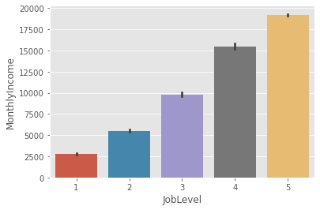

```python
sns.barplot(x='JobLevel', y='MonthlyIncome', data=employee_data)
```

### 5.4 Statsmodels Library

*Provides many different statistical models, statistical tests, and statistical data exploration*

- https://www.statsmodels.org/stable/index.html

```python
# import the statsmodels library
import statsmodels.api as sm
import statsmodels.formula.api as smf
```

```python
# OLS regression with one explanatory variable
results_ols = smf.ols('MonthlyIncome ~ YearsAtCompany', data=employee_data).fit()
print(results_ols.summary())
```

```
                            OLS Regression Results
==============================================================================
Dep. Variable:          MonthlyIncome   R-squared:                       0.264
Model:                            OLS   Adj. R-squared:                  0.264
Method:                 Least Squares   F-statistic:                     527.9
Date:                Thu, 06 Oct 2022   Prob (F-statistic):          4.82e-100
Time:                        17:36:09   Log-Likelihood:                -14291.
No. Observations:                1470   AIC:                         2.859e+04
Df Residuals:                    1468   BIC:                         2.860e+04
Df Model:                           1
Covariance Type:            nonrobust
==================================================================================
                     coef    std err          t      P>|t|      [0.025      0.975]
----------------------------------------------------------------------------------
Intercept       3733.2731    160.091     23.320      0.000    3419.242    4047.305
YearsAtCompany   395.2046     17.201     22.976      0.000     361.464     428.945
==============================================================================
Omnibus:                      387.315   Durbin-Watson:                   2.034
Prob(Omnibus):                  0.000   Jarque-Bera (JB):              875.316
Skew:                           1.462   Prob(JB):                    8.46e-191
Kurtosis:                       5.395   Cond. No.                         14.2
==============================================================================

Notes:
[1] Standard Errors assume that the covariance matrix of the errors is correctly specified.
```

```python
# OLS regression with several explanatory variables
results_ols2 = smf.ols('MonthlyIncome ~ YearsAtCompany + C(JobLevel) + C(Gender)+ C(Department)',
                       data = employee_data).fit()
print(results_ols2.summary())
```

```
                            OLS Regression Results
==============================================================================
Dep. Variable:          MonthlyIncome   R-squared:                       0.925
Model:                            OLS   Adj. R-squared:                  0.925
Method:                 Least Squares   F-statistic:                     2261.
Date:                Thu, 06 Oct 2022   Prob (F-statistic):               0.00
Time:                        17:36:09   Log-Likelihood:                -12611.
No. Observations:                1470   AIC:                         2.524e+04
Df Residuals:                    1461   BIC:                         2.529e+04
Df Model:                           8
Covariance Type:            nonrobust
===========================================================================================================
                                              coef    std err          t      P>|t|      [0.025      0.975]
-----------------------------------------------------------------------------------------------------------
Intercept                                2767.2186    175.734     15.747      0.000    2422.501    3111.936
C(JobLevel)[T.2]                         2734.0053     84.504     32.354      0.000    2568.244    2899.767
C(JobLevel)[T.3]                         7041.1370    111.312     63.256      0.000    6822.789    7259.485
C(JobLevel)[T.4]                         1.272e+04    152.700     83.292      0.000    1.24e+04     1.3e+04
C(JobLevel)[T.5]                         1.639e+04    180.641     90.754      0.000     1.6e+04    1.67e+04
C(Gender)[T.Male]                          20.5491     68.932      0.298      0.766    -114.667     155.765
C(Department)[T.Research & Development]    12.1602    168.368      0.072      0.942    -318.109     342.430
C(Department)[T.Sales]                    -58.3886    176.856     -0.330      0.741    -405.307     288.530
YearsAtCompany                              1.3051      6.526      0.200      0.842     -11.496      14.107
==============================================================================
Omnibus:                       98.789   Durbin-Watson:                   2.011
Prob(Omnibus):                  0.000   Jarque-Bera (JB):              202.447
Skew:                           0.440   Prob(JB):                     1.09e-44
Kurtosis:                       4.590   Cond. No.                         80.4
==============================================================================

Notes:
[1] Standard Errors assume that the covariance matrix of the errors is correctly specified.
```

```python
# Logit regression with one explanatory variable
results_logit = smf.logit('dummy_exit ~ MonthlyIncome', data=employee_data).fit()

print(results_logit.summary())
```

```
Optimization terminated successfully.
         Current function value: 0.426223
         Iterations 7
                           Logit Regression Results
==============================================================================
Dep. Variable:             dummy_exit   No. Observations:                 1470
Model:                          Logit   Df Residuals:                     1468
Method:                           MLE   Df Model:                            1
Date:                Thu, 06 Oct 2022   Pseudo R-squ.:                 0.03503
Time:                        17:36:09   Log-Likelihood:                -626.55
converged:                       True   LL-Null:                       -649.29
Covariance Type:            nonrobust   LLR p-value:                 1.537e-11
=================================================================================
                    coef    std err          z      P>|z|      [0.025      0.975]
---------------------------------------------------------------------------------
Intercept        -0.9291      0.129     -7.191      0.000      -1.182      -0.676
MonthlyIncome    -0.0001   2.16e-05     -5.879      0.000      -0.000   -8.47e-05
=================================================================================
```

```python
# Logit regression with several explanatory variables
results_logit2 = smf.logit(
    'dummy_exit ~ MonthlyIncome + Age + C(JobLevel) + C(WorkLifeBalance) + C(JobSatisfaction) + TrainingTimesLastYear',
    data=employee_data
).fit()

print(results_logit2.summary())
```

```
Optimization terminated successfully.
         Current function value: 0.398650
         Iterations 7
                           Logit Regression Results
==============================================================================
Dep. Variable:             dummy_exit   No. Observations:                 1470
Model:                          Logit   Df Residuals:                     1456
Method:                           MLE   Df Model:                           13
Date:                Thu, 06 Oct 2022   Pseudo R-squ.:                 0.09745
Time:                        17:36:09   Log-Likelihood:                -586.02
converged:                       True   LL-Null:                       -649.29
Covariance Type:            nonrobust   LLR p-value:                 1.014e-20
===========================================================================================
                              coef    std err          z      P>|z|      [0.025      0.975]
-------------------------------------------------------------------------------------------
Intercept                   2.1105      0.502      4.206      0.000       1.127       3.094
C(JobLevel)[T.2]           -0.6841      0.246     -2.781      0.005      -1.166      -0.202
C(JobLevel)[T.3]            0.5053      0.496      1.019      0.308      -0.466       1.477
C(JobLevel)[T.4]            0.3147      0.950      0.331      0.740      -1.547       2.176
C(JobLevel)[T.5]            1.4698      1.185      1.241      0.215      -0.852       3.792
C(WorkLifeBalance)[T.2]    -0.7933      0.299     -2.656      0.008      -1.379      -0.208
C(WorkLifeBalance)[T.3]    -1.0332      0.277     -3.734      0.000      -1.576      -0.491
C(WorkLifeBalance)[T.4]    -0.7017      0.341     -2.057      0.040      -1.370      -0.033
C(JobSatisfaction)[T.2]    -0.4851      0.225     -2.160      0.031      -0.925      -0.045
C(JobSatisfaction)[T.3]    -0.4605      0.200     -2.307      0.021      -0.852      -0.069
C(JobSatisfaction)[T.4]    -0.9102      0.212     -4.285      0.000      -1.326      -0.494
MonthlyIncome              -0.0001   6.61e-05     -2.267      0.023      -0.000   -2.03e-05
Age                        -0.0308      0.010     -3.144      0.002      -0.050      -0.012
TrainingTimesLastYear      -0.1414      0.060     -2.363      0.018      -0.259      -0.024
===========================================================================================
```

```python
# Display multiple regressions in one table, as in scientific papers

from statsmodels.iolib.summary2 import summary_col

print(summary_col([results_logit, results_logit2], stars=True))
```

```
==================================================
                        dummy_exit I dummy_exit II
--------------------------------------------------
Age                                  -0.0308***
                                     (0.0098)
C(JobLevel)[T.2]                     -0.6841***
                                     (0.2460)
C(JobLevel)[T.3]                     0.5053
                                     (0.4957)
C(JobLevel)[T.4]                     0.3147
                                     (0.9497)
C(JobLevel)[T.5]                     1.4698
                                     (1.1847)
C(JobSatisfaction)[T.2]              -0.4851**
                                     (0.2246)
C(JobSatisfaction)[T.3]              -0.4605**
                                     (0.1996)
C(JobSatisfaction)[T.4]              -0.9102***
                                     (0.2124)
C(WorkLifeBalance)[T.2]              -0.7933***
                                     (0.2986)
C(WorkLifeBalance)[T.3]              -1.0332***
                                     (0.2767)
C(WorkLifeBalance)[T.4]              -0.7017**
                                     (0.3411)
Intercept               -0.9291***   2.1105***
                        (0.1292)     (0.5018)
MonthlyIncome           -0.0001***   -0.0001**
                        (0.0000)     (0.0001)
TrainingTimesLastYear                -0.1414**
                                     (0.0598)
==================================================
Standard errors in parentheses.
* p<.1, ** p<.05, ***p<.01
```

### 5.5 Scikit-learn Library

*Provides general-purpose machine learning package with extensive coverage of models and feature transformers*

- Not part of the introductory session, but will be introduced in a later part of the course

# 6. References and Further Readings

The lecture and tutorial materials we provide will enable you to prepare for the exam. None of the sources below are compulsory, but they might be helpful in addition.

- Employee data used in this tutorial: https://www.kaggle.com/datasets/pavansubhasht/ibm-hr-analytics-attrition-dataset
- VanderPlas, Jake (2016). Python Data Science Handbook: Essential Tools for Working with Data. O'Reilly Media.
- McKinney, Wes (2012). Python for Data Analysis. O'Reilly Media.
- Rule et al. (2018). "Ten simple rules for writing and sharing computational analyses in Jupyter Notebooks". In: PLoS Computational Biology 15.7: e1007007.
- Athey, Susan and Guido W. Imbens (2019). "Machine Learning Methods That Economists Should Know About". In: Annual Review of Economics 11, pp. 685-725.
- Breiman, Leo (2001). "Statistical Modeling: The Two Cultures". In: Statistical Science 16.3, pp.199-231.
- Hastie, Trevor, Tibshirani, Robert, and Jerome Friedman (2017). Elements of Statistical Learning. Springer Science & Business Media.
- Mullainathan, Sendhil and Jann Spiess (2017). "Machine Learning: An Applied Econometric Approach". In: Journal of Economic Perspectives 31.2, pp. 87-106.
- Adams, Douglas (2008): The Hitchhiker's Guide to the Galaxy. Reclam.